# Section 203 Language Coverage Determinations

Section 203 of the Voting Rights Act, and the survey that decides who gets a ballot they can read

Democracy’s Data

Last updated September 13, 2026 at 10:53a EDT

A ballot a citizen cannot read is a barrier of the same kind as a literacy test. Congress decided exactly that in 1975, when it added [Section 203](https://www.law.cornell.edu/uscode/text/52/10503) to the Voting Rights Act and made the translated ballot a right rather than a courtesy.[^1] Where enough voting-age citizens of a language minority speak English less than very well, the county **must** provide election materials in their language, with a federal court behind the obligation. The right switches on at a number, and the number comes from a survey.

In December 2021 the Census Bureau published that number for Solano County, California. It said that 9,943 of the county’s voting-age citizens were of Hispanic origin and spoke English less than very well. That number is an **estimate**, worked up from a sample of households rather than a count of everyone, and in the next column of the same row the Bureau published the margin of error, which says how far off it could be: plus or minus 377.

The statute names a threshold of ten thousand. Solano County came in 57 people short, so Solano County owes its Spanish-speaking citizens nothing. A few rows away sits Philadelphia County, whose estimate for its Chinese-speaking citizens is 10,150, over the line by 150, with a margin of plus or minus 450. Philadelphia must translate its ballots, instructions, notices and polling-place assistance into Chinese for the next five years.

The law draws a bright line. Can the instrument that feeds it draw one too? This brief opens the file the determinations were made from and reads the one column the statute ignores.

## The test

The test uses the decision itself: the Census Bureau’s *2021 Section 203 Determinations* public use file, downloadable from the Bureau’s [determinations page](https://www.census.gov/programs-surveys/decennial-census/about/voting-rights/voting-rights-determination-file.html). The Bureau published it on 8 December 2021, beside the [notice in the *Federal Register*](https://www.federalregister.gov/documents/2021/12/08/2021-26547/voting-rights-act-amendments-of-2006-determinations-under-section-203), the government’s daily journal of official announcements. Nobody reconstructed this arithmetic. The Director of the Census is required to run the test, and this file is the run, with the flags the Bureau set and the estimates it set them from.

Every estimate in it comes from the American Community Survey, with five years of answers, 2015 through 2019, pooled together so that the sample is large enough to say something about a small county. The American Community Survey chapter is that survey’s biography: roughly 3.5 million addresses a year, each answering household standing in for the many that were not asked, and a margin of error beside every estimate. Asking whether a legal line falls inside its own measurement error takes a file that publishes both, and almost no administrative file does. This one does, in adjacent columns, in every row, which is why this source, of all sources, can answer the question.

## The data

The statute’s rule comes first. A jurisdiction is covered for a language group if **either**

- more than **10,000** of its voting-age citizens are in that group and have limited English, **or**
- more than **5%** of its voting-age citizens are,

**and** that group’s illiteracy rate exceeds the national rate, itself a survey estimate recomputed each cycle. The legal facts here are the statute’s, at [52 U.S.C. §10503](https://www.law.cornell.edu/uscode/text/52/10503); the arithmetic about them is measured here and can be re-measured by anyone.

Before any threshold applies, the statute decides who can be counted at all. A language minority group means, at [52 U.S.C. §10310(c)(3)](https://www.law.cornell.edu/uscode/text/52/10310), persons who are American Indian, Asian American, Alaskan Native or of Spanish heritage: four groups, listed in 1975, unchanged since. The file reports 72 language categories and every one sits inside the four. A county with fifty thousand limited-English Arabic speakers is not covered and cannot become covered, because only Congress can revise the list.

Two tables drawn from the Bureau’s file are read here: `sect203_counties.csv`, every county-language pair with any limited-English population (23,054 rows), and `sect203_determined.csv`, every jurisdiction the Bureau issued a determination about.

| Quantity | Value |
| --- | --- |
| Coverage determinations issued | 391 |
| Distinct jurisdictions covered | 334 |
| of which counties | 245 |
| of which minor civil divisions | 86 |
| of which whole states | 3 |
| Determinations for Spanish (recorded as ‘Hispanic’) | 235 |

That is 334 jurisdictions carrying 391 determinations, some places being covered for more than one language; 235 determinations are for Spanish. The counts match the Bureau’s announcement of 331 counties and minor civil divisions (the townships and similar units that sit below the county in some states) plus 3 states.

One row is one county and one language group. Here is the largest such row in the country:

| Jurisdiction | Language group | Voting-age citizens | Of them, limited English | Margin of error | % of all | 10,000 test | 5% test | Illiteracy test | Covered |
| --- | --- | --- | --- | --- | --- | --- | --- | --- | --- |
| Los Angeles County | Hispanic | 2,452,000 | 554,700 | 2,489 | 8.8 | 1 | 1 | 1 | 1 |

Six columns carry the whole determination. The last four are **flags**, a `1` where the row passes a test and a `0` where it does not, and the final one is the only one with legal force: a `1` under *covered* is an obligation on a county government. `VACLEP` is the estimate the statute turns on. **`MVACLEP` is the margin of error the Bureau publishes next to it**, computed by the same office, and it is the column nothing in the law consults.

The Bureau’s file covers nine levels of geography, from whole states down to Native villages. The tables here keep the county rows, drop county-language pairs with no limited-English population, and read blank coverage flags as zeros. That last step is almost certainly what the Bureau means, and it is still a decision made on the reader’s behalf. Read the blanks as missing instead and every count of covered places below changes, because a convention did.

> **Before you read on, commit to an answer.** You have both counties’ numbers: 9,943 give or take 377 in Solano, 10,150 give or take 450 in Philadelphia. Turn each into a range and write down two things: do the ranges miss each other, touch at the edges, or mostly overlap; and how many contain ten thousand — neither, one, or both?

## What it says about democracy

Start with what the file establishes: American language access reaches far past the Spanish-language ballot most people picture.

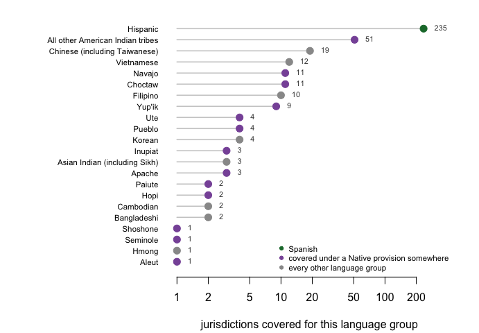

**Figure 1. Every language group that triggers coverage anywhere in the United States.** One dot per group on a logarithmic scale, which steps by multiples rather than equal amounts, because a linear axis would flatten everyone behind Spanish to nothing. Spanish accounts for 235 of the 391 determinations, and 4 of the 22 groups are covered in a single jurisdiction each. 13 groups are covered somewhere under the American Indian or Alaska Native provisions rather than the numeric tests.

Aleut. Hmong. Seminole. Shoshone. **Somewhere in America a county must print its ballots in Shoshone**, because enough Shoshone speakers live there and Congress decided this was a right and not a gesture.

The arithmetic behind it is honest. The file carries a flag for each statutory test, and the flag can be checked against the estimate it summarizes:

| Test | Value |
| --- | --- |
| Rows where the estimate exceeds 10,000 | 130 |
| Rows where the file’s 10,000 flag is set | 130 |
| Do they agree, row for row? | TRUE |

No discretion, no rounding, no thumb near the scale: above ten thousand the flag is on, below it off, in all 23,054 rows. The difficulty that follows is not the Bureau’s. It sits between a rule that demands an exact answer and a survey that produces a range.

Now the prediction. Take Solano first: subtract the margin from the estimate for the low end and add it for the high end, and the interval runs from 9,566 to 10,320. Philadelphia’s, worked the same way, runs from 9,700 to 10,600. Most readers write down that the ranges clear each other, or at worst brush at the edges. Instead they overlap along almost their whole length, and both contain ten thousand. On the evidence the federal government itself published, these two counties cannot be told apart.

They are not alone. Here is every county whose published interval contains the statutory line:

| County | Language | Estimate | Margin of error | Low end | High end | Covered |
| --- | --- | --- | --- | --- | --- | --- |
| Adams County | Hispanic | 10,340 | 429 | 9,911 | 10,769 | 1 |
| Dallas County | Vietnamese | 10,190 | 525 | 9,665 | 10,715 | 1 |
| Philadelphia County | Chinese (including Taiwanese) | 10,150 | 450 | 9,700 | 10,600 | 1 |
| Solano County | Hispanic | 9,943 | 377 | 9,566 | 10,320 | 0 |
| Fairfax County | Korean | 9,934 | 460 | 9,474 | 10,394 | 0 |
| Pinal County | Hispanic | 9,865 | 388 | 9,477 | 10,253 | 0 |
| Kings County | Hispanic | 9,773 | 319 | 9,454 | 10,092 | 1 |
| Los Angeles County | Japanese | 9,667 | 358 | 9,309 | 10,025 | 0 |

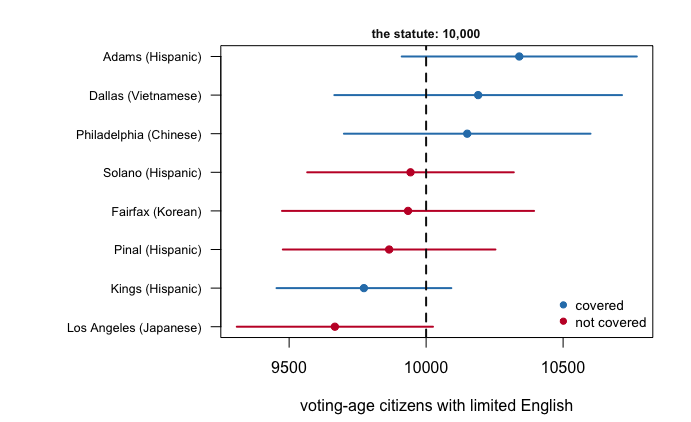

**Figure 2. Every county whose published interval contains the statutory line.** The dot is the Bureau’s estimate, the bar is the margin it published alongside, and the dashed line is the number in the statute. Every bar crosses it. The color is the legal consequence, decided by where the dot happens to fall: 4 of these 8 counties are covered and 4 are not.

Philadelphia’s margin is 3.0 times the distance by which it clears the line. Solano’s is 6.6 times the distance by which it misses. The law sorts these rows cleanly into two kinds; the survey declines to sort them at all. **The law has no category for “we cannot tell.”**

The percentage test is quietly worse.

| Quantity | Value |
| --- | --- |
| Counties whose interval straddles the 5% line | 51 |
| of them covered | 27 |
| of them not covered | 24 |
| For comparison: counties straddling the 10,000 line | 8 |

**51 counties cannot be placed on the 5% line by their own estimate**, about 6.4 times as many as on the count rule. A percentage carries an estimate on top, in its numerator, the top number of the fraction, and another underneath, in its denominator, the number being divided by. Both come from a sample of the county, and the smaller the county, the wider the margin on both.

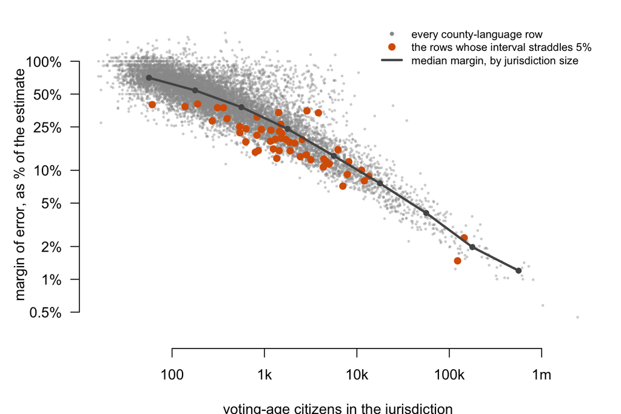

**Figure 3. The smaller the jurisdiction, the wider the margin of error as a share of the estimate.** One dot per county-language row, both axes logarithmic. Among the smallest jurisdictions here, near 56 voting-age citizens, the published margin runs to a median of 70.6% of the estimate itself, meaning half those rows carry a wider margin than that and half a narrower one; near 562,341 citizens it falls to 1.2%. The highlighted rows straddle the 5% line, on the wide side of the funnel. The rule is least able to say what it means exactly where a translated ballot would be noticed most.

The statute’s third condition, the illiteracy test, turns out to be no condition at all. 10,411 of the file’s 23,054 rows fail it, yet not one row clearing either numeric bar is stopped by it. A group that large essentially always has an illiteracy rate above the national one.

Congress has already conceded the deeper point once. The most interesting rows in the file are covered while failing every numeric test:

| Jurisdiction | Language | Limited-English citizens | % of all | American Indian provision | Alaska Native provision | Covered |
| --- | --- | --- | --- | --- | --- | --- |
| Coconino County | Paiute | 1 | 0.0 | 1 | 0 | 1 |
| Clearwater County | All other American Indian tribes | 1 | 0.0 | 1 | 0 | 1 |
| Yukon-Koyukuk Census Area | Inupiat | 2 | 0.1 | 0 | 1 | 1 |
| Bristol Bay Borough | Yup’ik | 3 | 0.4 | 0 | 1 | 1 |
| Apache County | Pueblo | 3 | 0.0 | 1 | 0 | 1 |

There are 46 such rows, and the smallest estimate among them is 1. For American Indian areas and Alaska Native regions the statute works on the reservation or the Native village, not the county containing it. Where the population is very small, it stops trying to measure and simply covers. That is not a sentimental carve-out; it is a correction for a known defect in the instrument. The defect it corrects is the funnel in Figure 3, and the funnel is not confined to Alaska.

Last, the threshold itself. If ten thousand captured some real feature of American language communities, the distribution of estimates should show it. It does not.

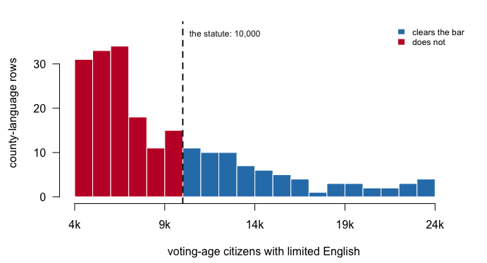

**Figure 4. There is no cliff at ten thousand.** County-language rows near the threshold, in bins a thousand wide. The distribution decays smoothly through the statutory line: the bin just below it holds 15 rows and the bin just above holds 11. The color changes where the statute says so, and the data does not.

Lower the line to nine thousand and 15 county-language pairs join the covered side; raise it to twelve and a half thousand and 29 drop off. A round number chosen in 1975 decides coverage for dozens of jurisdictions, and the distribution offers no reason to prefer it to its neighbors.

The strongest defense of the rule is that any alternative is worse. A discretionary standard invites litigation and hands the decision to the least accountable actor; a bright line administers itself, which Tucker (2009) argues is why the provision has survived reauthorization.[^2] The Act’s other formula, Section 4(b), which decided which states had to clear any change in their voting rules with the federal government in advance, died in [*Shelby County v. Holder*](https://www.law.cornell.edu/supremecourt/text/12-96) (2013) for resting on 1960s data. **Section 203 is the formula that is updated**, every five years, and the cost of that virtue is the instability documented above. A county in the straddle band can change legal status between cycles without anybody moving, and the next determination is due in 2026.

## What this brief cannot tell you

**Whether any county was misclassified, or whether coverage works.** A margin of error is not an error, and every estimate here may be very close to the truth; the file cannot say, and the statute proceeds as though it could. No column measures registration, turnout, or whether a translated ballot ever changed a vote. A `1` in the covered column is an obligation on a county government, not a ballot in anybody’s hand.

**The geography the hardest determinations were made on.** The extract is the county level. 635 of the 1,181 determined rows sit at other levels: minor civil divisions, whole states, and the Native areas where the survey struggles most.

**Whether the straddle counties actually flip.** This is a single determination cycle. Whether a county changes sides at the next one without anyone moving needs earlier cycles laid beside this one, in a matched form the public files do not offer.

**What was actually measured.** Nobody has ever tested whether an American can read a ballot. The estimate counts people whose household said they speak English less than very well, one member answering for all. And the determinations are made for “Hispanic” people rather than Spanish speakers, because the statute defines its groups by heritage. The two are close enough that the mismatch rarely bites, and far enough apart that a careful reader should know it is there.

## What you should have learned

- A civil right switches on at a survey estimate: 334 jurisdictions carry 391 language coverage determinations, computed by the Census Bureau with no hearing and no appeal.
- The Bureau’s arithmetic is faithful to the statute in all 23,054 county-language rows. The difficulty is the statute’s: it reads an estimate as though it were a count.
- 8 counties straddle the 10,000-person line and 51 straddle the 5% line, so 59 legal determinations turn on where inside its own margin an estimate happened to land.
- The uncertainty is largest exactly where the statute aims: among the smallest jurisdictions in the file the median margin runs to 70.6% of the estimate itself.
- Congress has already corrected for the instrument once, covering 46 small Native communities without measuring them, and the defect that correction admits is not confined to them.

## Extensions

- `sect203_counties.csv` has `LEPPCT` and `MLEPPCT` beside the coverage flags. Sort by how close `LEPPCT` sits to 5. What separates two counties on opposite sides of the line?
- In `sect203_counties.csv`, compute `MVACLEP` as a share of `VACLEP` and sort by it. Would you switch a right on or off at the top of that list?
- `sect203_determined.csv` holds every covered jurisdiction. Group by `LANGUAGE`: which languages carry the most obligations, and which appear only once or twice?
- Look up your own county in `sect203_counties.csv` by `NAMELSAD`. Which language rows does it have, and what would have to change for a flag to change?
- **Stretch.** The Bureau published determinations in 2016 as well. Download that cycle’s file and find the counties that changed status between the two cycles. How many sat in this brief’s straddle band?
- **Stretch.** Pick one covered county and find its translated election materials online: what did the obligation actually produce?

## Sources

**Data**

- U.S. Census Bureau, Redistricting and Voting Rights Data Office, *2021 Section 203 Determinations — Public Use File*. https://www.census.gov/programs-surveys/decennial-census/about/voting-rights/voting-rights-determination-file.html Published 8 December 2021, from American Community Survey estimates for 2015–2019 and 2020 Census population counts.

**Law and literature**

- Voting Rights Act §203, 52 U.S.C. §10503. https://www.law.cornell.edu/uscode/text/52/10503
- Voting Rights Act §14(c)(3), 52 U.S.C. §10310(c)(3), the four-group definition of a language minority group. https://www.law.cornell.edu/uscode/text/52/10310
- “Voting Rights Act Amendments of 2006, Determinations Under Section 203,” *Federal Register* 86: 69611 (8 December 2021). https://www.federalregister.gov/documents/2021/12/08/2021-26547/voting-rights-act-amendments-of-2006-determinations-under-section-203
- Voting Rights Act Amendments of 1975, Pub. L. 94-73, 89 Stat. 400, the act that added Section 203. https://www.govinfo.gov/content/pkg/STATUTE-89/pdf/STATUTE-89-Pg400.pdf
- U.S. Department of Justice, Civil Rights Division, *Language Minority Citizens*, a plain-language account of what Section 203 requires. https://www.justice.gov/crt/language-minority-citizens
- *Shelby County v. Holder*, 570 U.S. 529 (2013). https://supreme.justia.com/cases/federal/us/570/529/ https://www.law.cornell.edu/supremecourt/text/12-96
- Tucker, J. T. (2009). *The Battle Over Bilingual Ballots: Language Minorities and Political Access Under the Voting Rights Act.* Farnham: Ashgate. https://www.routledge.com/The-Battle-Over-Bilingual-Ballots-Language-Minorities-and-Political-Access-Under-the-Voting-Rights-Act/Tucker/p/book/9781138260986

**The data itself**

Every figure above is drawn from these tables. They are plain CSV, they open in a spreadsheet, and they are yours to take further.

`sect203_counties.csv`, `sect203_determined.csv`

Rebuild this data yourself, with an AI assistant

```
I want to rebuild a public dataset from its original source, without any
starting files. Please do the following and show your work.

THE SOURCE. U.S. Census Bureau, Redistricting and Voting Rights Data
Office, "2021 Section 203 Determinations -- Public Use File". The
Voting Rights Act requires ballots and election materials in a
minority language wherever enough voting-age citizens speak it and
speak English less than very well; this file is the actual arithmetic
behind those legal determinations, made in December 2021 from
2015-2019 American Community Survey data. One zip of about 4.3 MB
that expands to roughly 120 MB of CSVs:
https://www2.census.gov/programs-surveys/decennial/rdo/datasets/2021/2021_Section203-Determinations/Sec203_PUF_2021_12_01.zip
No account or key is needed. One row is one jurisdiction-language
pair: voting-age citizens, the limited-English-proficiency count
among them, the illiteracy rate, each with its margin of error, and
flags recording which statutory tests the pair met. One CSV inside
holds only the pairs the Bureau made determinations about; a much
larger one holds every county.

WHAT TO BUILD.
1. The determined pairs, with their estimates, margins and flags --
   and a count of how many were covered, meaning the jurisdiction
   must by law provide election materials in that language.
2. A county-language table for every pair with any limited-English
   population at all. This is what makes the near misses visible:
   the statute's thresholds are sharp, and the survey estimates they
   cut through are not.

CHECK YOUR WORK. The copy this book used was downloaded in August 2026.
If your rebuild matches it, you should find:
- 1,181 determined jurisdiction-language rows
- 23,054 county-language rows
- California's statewide Hispanic row: 7,593,000 voting-age
  citizens, of whom 1,467,000 are limited-English
Determinations are issued every five years, each as its own file;
the 2021 file is frozen as published, and a newer determination is a
new dataset, not a revision of this one.
```

[^1]: Voting Rights Act Amendments of 1975, Pub. L. 94-73, 89 Stat. 400: https://www.govinfo.gov/content/pkg/STATUTE-89/pdf/STATUTE-89-Pg400.pdf. The section now sits at 52 U.S.C. §10503. The Justice Department’s plain-language summary of what it requires is at https://www.justice.gov/crt/language-minority-citizens.
[^2]: James Thomas Tucker, *The Battle Over Bilingual Ballots: Language Minorities and Political Access Under the Voting Rights Act* (Farnham: Ashgate, 2009), https://www.routledge.com/The-Battle-Over-Bilingual-Ballots-Language-Minorities-and-Political-Access-Under-the-Voting-Rights-Act/Tucker/p/book/9781138260986.